# Cybersecurity Intrusion

Cybersecurity systems often need to identify suspicious network sessions so potential attacks can be identified and investigated. Our goal is to build a machine learning model that predicts whether a network session is **Normal** or an **Attack** using network behavior, login activity, browser information, encryption type, IP reputation, and other features from our dataset.

This is important because missing an attack can be costly. A model that identifies suspicious sessions could help security teams prioritize which sessions need closer review. However, false alarms also matter because too many unnecessary alerts can mislead security teams. Therefore, this project evaluates performance using not only accuracy, but also precision, recall, F1, F2, ROC AUC, and average precision, with extra focus on recall and F2-score because catching attacks is especially important.

Target Feature: '**attack_detected**'

- 0 --> Normal
- 1 --> Attack

## Feature Descriptions

| Feature | Type | Description |
| --- | --- | --- |
| `session_id` | Identifier | Unique ID for each session record |
| `network_packet_size` | Numeric | Size of the network packet associated with the session |
| `protocol_type` | Categorical | Network protocol used by the session: **TCP**, **UDP**, or **ICMP** |
| `login_attempts` | Numeric | Number of login attempts for the session |
| `session_duration` | Numeric | Duration of the session |
| `encryption_used` | Categorical | Encryption method used: **AES**, **DES**, or **None** |
| `ip_reputation_score` | Numeric | Score representing how trustworthy or suspicious the IP address appears on a 0-1 scale, with **1** being suspicious |
| `failed_logins` | Numeric | Number of failed login attempts for the session |
| `browser_type` | Categorical | Browser associated with the session: **Chrome**, **Firefox**, **Edge**, **Safari**, and **Unknown**. |
| `unusual_time_access` | Binary | Indicates whether access occurred at an unusual time |
| `attack_detected` | Target | Indicates whether the session was labeled as an attack. `0 = Normal`, `1 = Attack` |

### Import libraries and Load data

## 1. Check and Clean the Data

First we check that the data is loaded as expected looking at the head, tail, and shape of the data (rows & cols)

|  | session_id | network_packet_size | protocol_type | login_attempts | session_duration | encryption_used | ip_reputation_score | failed_logins | browser_type | unusual_time_access | attack_detected |
| --- | --- | --- | --- | --- | --- | --- | --- | --- | --- | --- | --- |
| 0 | SID_00001 | 599 | TCP | 4 | 492.983263 | DES | 0.606818 | 1 | Edge | 0 | 1 |
| 1 | SID_00002 | 472 | TCP | 3 | 1557.996461 | DES | 0.301569 | 0 | Firefox | 0 | 0 |
| 2 | SID_00003 | 629 | TCP | 3 | 75.044262 | DES | 0.739164 | 2 | Chrome | 0 | 1 |
| 3 | SID_00004 | 804 | UDP | 4 | 601.248835 | DES | 0.123267 | 0 | Unknown | 0 | 1 |
| 4 | SID_00005 | 453 | TCP | 5 | 532.540888 | AES | 0.054874 | 1 | Firefox | 0 | 0 |
| ... | ... | ... | ... | ... | ... | ... | ... | ... | ... | ... | ... |
| 9532 | SID_09533 | 194 | ICMP | 3 | 226.049889 | AES | 0.517737 | 3 | Chrome | 0 | 1 |
| 9533 | SID_09534 | 380 | TCP | 3 | 182.848475 | None | 0.408485 | 0 | Chrome | 0 | 0 |
| 9534 | SID_09535 | 664 | TCP | 5 | 35.170248 | AES | 0.359200 | 1 | Firefox | 0 | 0 |
| 9535 | SID_09536 | 406 | TCP | 4 | 86.664703 | AES | 0.537417 | 1 | Chrome | 1 | 0 |
| 9536 | SID_09537 | 340 | TCP | 6 | 86.876744 | None | 0.277069 | 4 | Chrome | 1 | 1 |

9537 rows × 11 columns

- The data appears to be loaded correctly as the columns title and data appear to line up as expected.

Next We'll look at column details and check for any missing or duplicate data

```
<class 'pandas.DataFrame'>
RangeIndex: 9537 entries, 0 to 9536
Data columns (total 11 columns):
 #   Column               Non-Null Count  Dtype
---  ------               --------------  -----
 0   session_id           9537 non-null   str
 1   network_packet_size  9537 non-null   int64
 2   protocol_type        9537 non-null   str
 3   login_attempts       9537 non-null   int64
 4   session_duration     9537 non-null   float64
 5   encryption_used      9537 non-null   str
 6   ip_reputation_score  9537 non-null   float64
 7   failed_logins        9537 non-null   int64
 8   browser_type         9537 non-null   str
 9   unusual_time_access  9537 non-null   int64
 10  attack_detected      9537 non-null   int64
dtypes: float64(2), int64(5), str(4)
memory usage: 819.7 KB
```

|  | rows | columns | missing_values | duplicate_rows |
| --- | --- | --- | --- | --- |
| 0 | 9537 | 11 | 0 | 0 |

The raw dataset has 11 columns with no missing values or duplicate rows that appear in the dataset, so the only direct cleaning step in the final notebook is dropping **session_id** since that is a unique identifier and holds no predictive merit for the model to train with.

```
<class 'pandas.DataFrame'>
RangeIndex: 9537 entries, 0 to 9536
Data columns (total 10 columns):
 #   Column               Non-Null Count  Dtype
---  ------               --------------  -----
 0   network_packet_size  9537 non-null   int64
 1   protocol_type        9537 non-null   str
 2   login_attempts       9537 non-null   int64
 3   session_duration     9537 non-null   float64
 4   encryption_used      9537 non-null   str
 5   ip_reputation_score  9537 non-null   float64
 6   failed_logins        9537 non-null   int64
 7   browser_type         9537 non-null   str
 8   unusual_time_access  9537 non-null   int64
 9   attack_detected      9537 non-null   int64
dtypes: float64(2), int64(5), str(3)
memory usage: 745.2 KB
```

We'll look at statistical data about the numeric features

|  | count | mean | std | min | 25% | 50% | 75% | max |
| --- | --- | --- | --- | --- | --- | --- | --- | --- |
| network_packet_size | 9537.0 | 500.430639 | 198.379364 | 64.000000 | 365.000000 | 499.000000 | 635.000000 | 1285.000000 |
| login_attempts | 9537.0 | 4.032086 | 1.963012 | 1.000000 | 3.000000 | 4.000000 | 5.000000 | 13.000000 |
| session_duration | 9537.0 | 792.745312 | 786.560144 | 0.500000 | 231.953006 | 556.277457 | 1105.380602 | 7190.392213 |
| ip_reputation_score | 9537.0 | 0.331338 | 0.177175 | 0.002497 | 0.191946 | 0.314778 | 0.453388 | 0.924299 |
| failed_logins | 9537.0 | 1.517773 | 1.033988 | 0.000000 | 1.000000 | 1.000000 | 2.000000 | 5.000000 |
| unusual_time_access | 9537.0 | 0.149942 | 0.357034 | 0.000000 | 0.000000 | 0.000000 | 0.000000 | 1.000000 |
| attack_detected | 9537.0 | 0.447101 | 0.497220 | 0.000000 | 0.000000 | 0.000000 | 1.000000 | 1.000000 |

**Some Observations**:

- An interesting observation is the max **login_attempts** appear to be 13 and max **failed_logins** appear to be 5
- There appears to be a lot of deviation with **network_packet_size** and **session_duration**
- **attack_detected** and **unusual time access** are binary values in the dataset

## 2. EDA Visuals

We'll explore the data to understand our data. Our first look will be at our label **attack_detected** to see how much of our data consists of normal/attack

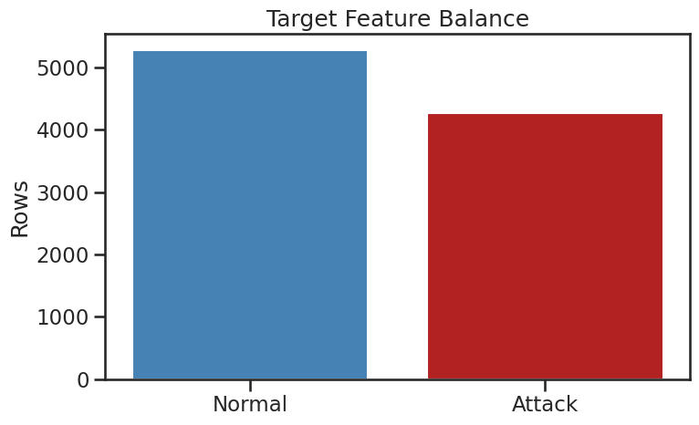

|  | normal count | attack count | attack proportion |
| --- | --- | --- | --- |
| 0 | 5273 | 4264 | 44.71% |

- Higher normal counts, but reasonably balanced

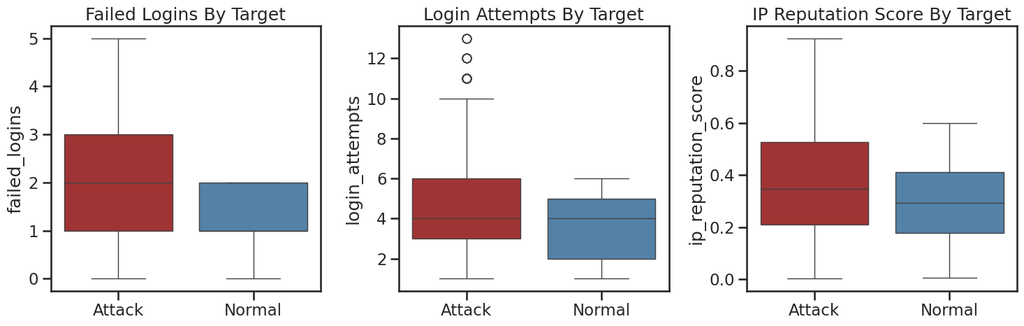

- The boxplots suggest that Login behavior and IP reputation provides a distinguishing signal between normal and attack.

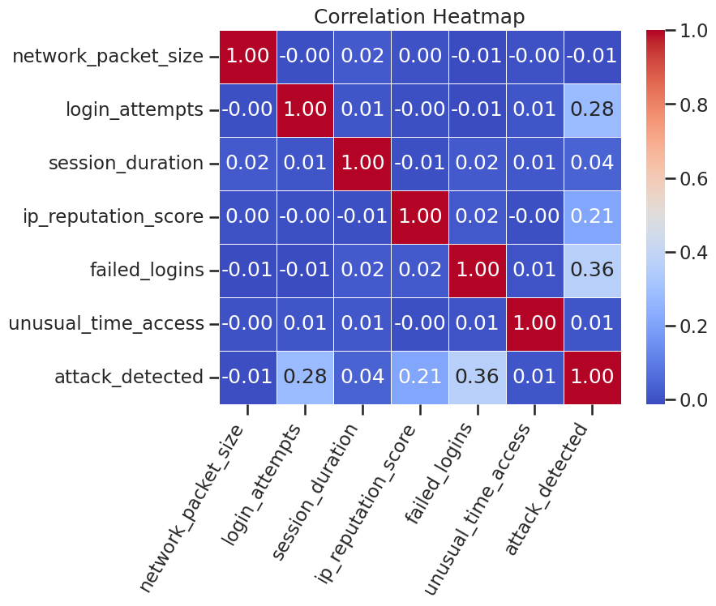

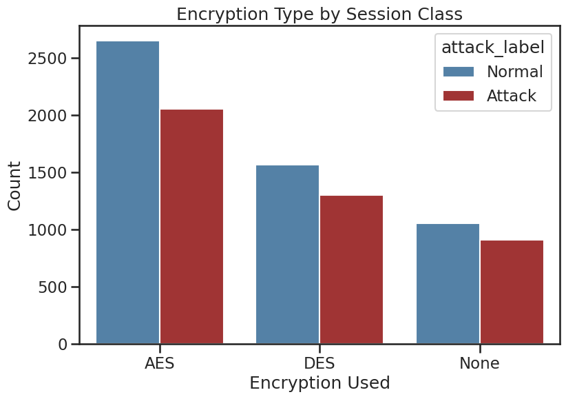

## 3. Failed Logins > Login Attempts Issue

During EDA, we found rows where `failed_logins` exceeded `login_attempts`. This logically doesn't make sense as you cannot fail more than you attempt.

```
Sample of invalid rows:
```

|  | login_attempts | failed_logins | ip_reputation_score | session_duration | browser_type | unusual_time_access | attack_detected |
| --- | --- | --- | --- | --- | --- | --- | --- |
| 17 | 1 | 2 | 0.136729 | 87.641002 | Firefox | 0 | 0 |
| 33 | 2 | 3 | 0.110269 | 1039.101186 | Chrome | 0 | 1 |
| 59 | 1 | 2 | 0.259419 | 989.889796 | Edge | 0 | 1 |
| 69 | 1 | 2 | 0.408654 | 1105.380602 | Chrome | 0 | 1 |
| 101 | 2 | 3 | 0.204681 | 294.584967 | Chrome | 0 | 1 |

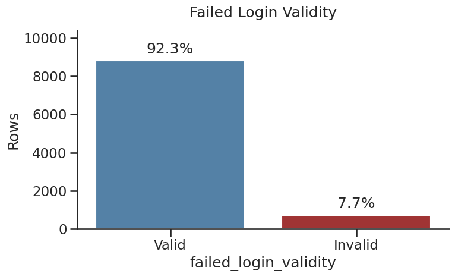

|  | valid rows | invalid rows | percent invalid | invalid attack proportion | valid attack proportion |
| --- | --- | --- | --- | --- | --- |
| 0 | 8807 | 730 | 7.65% | 70.68% | 42.56% |

- Several strategies were tested such as: removing invalid rows, adjusting failed login counts, creating ratio-based features, a few others. However, these approaches only reduced model performance. Thus, the raw dataset was kept so the analysis remained faithful to the source data. However, this issue is still important because it limits how confidently the model could be used in a real-world setting.

## 4. Feature Engineering

The raw dataset is kept as provided with a two engineered features that had the most impact. However, it's a slight improvement.

Engineered features:

```
Added engineered features: ['failed_login_reputation_score', 'login_attempt_reputation_score']
```

|  | network_packet_size | protocol_type | login_attempts | session_duration | encryption_used | ip_reputation_score | failed_logins | browser_type | unusual_time_access | attack_detected | failed_login_reputation_score | login_attempt_reputation_score |
| --- | --- | --- | --- | --- | --- | --- | --- | --- | --- | --- | --- | --- |
| 0 | 599 | TCP | 4 | 492.983263 | DES | 0.606818 | 1 | Edge | 0 | 1 | 1.213636 | 6.427272 |
| 1 | 472 | TCP | 3 | 1557.996461 | DES | 0.301569 | 0 | Firefox | 0 | 0 | 0.301569 | 3.904707 |
| 2 | 629 | TCP | 3 | 75.044262 | DES | 0.739164 | 2 | Chrome | 0 | 1 | 2.217493 | 5.217493 |
| 3 | 804 | UDP | 4 | 601.248835 | DES | 0.123267 | 0 | Unknown | 0 | 1 | 0.123267 | 4.493069 |
| 4 | 453 | TCP | 5 | 532.540888 | AES | 0.054874 | 1 | Firefox | 0 | 0 | 0.109748 | 5.274369 |

```
Model df shape: (9537, 12)
```

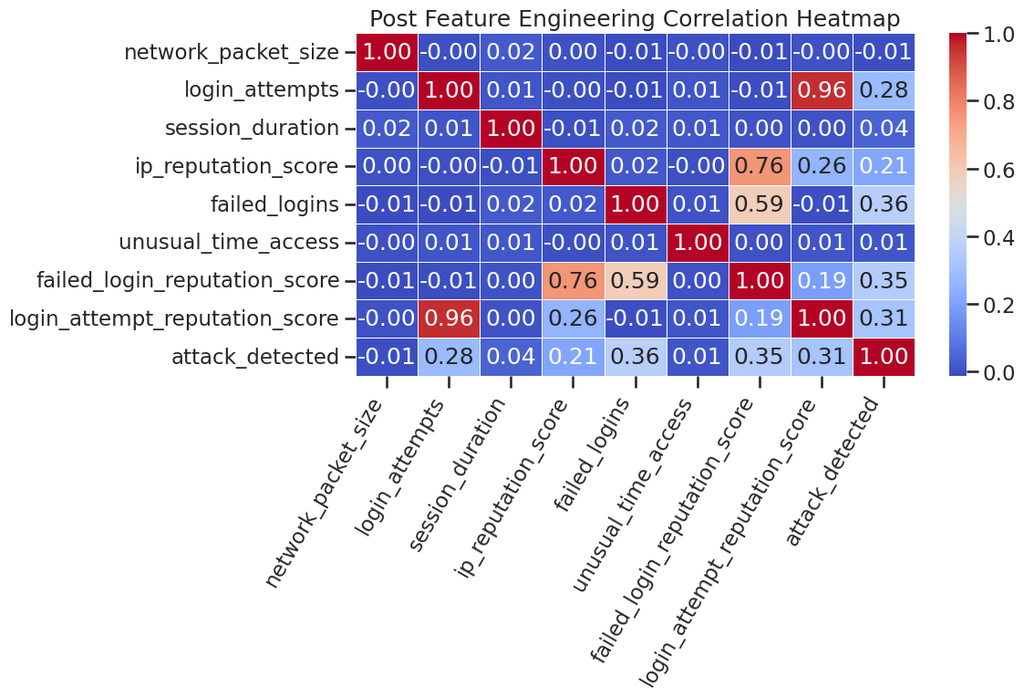

## 5. Modeling Setup

All models used the same preprocessing pipeline:

- Numeric features are standardized with `StandardScaler`
- Categorical features are encoded with `OneHotEncoder`

These preprocessing steps are placed inside a scikit-learn pipeline so the same transformations are applied consistently during cross-validation, final fitting, and prediction.

### Modeling Helper Functions

These helper functions keep the modeling workflow compact as they handle preprocessing via standard scaling & one hot encoding, model creation, evaluation, and creating visuals

## 6. Train/Test Split

A stratified 80/20 split is used so the train and test sets preserve the same attack/normal ratio

|  | split | X shape | y shape | attack proportion | % of data |
| --- | --- | --- | --- | --- | --- |
| 0 | train | (7629, 11) | 7629 | 0.447 | 80% |
| 1 | test | (1908, 11) | 1908 | 0.447 | 20% |

## 7. Model Comparison With Cross-Validation

`BaselineLogisticRegression` is included as a simple baseline model so that the candidate models can be compared against a straightforward linear approach.

Using the preprocessing pipeline described earlier, each candidate model is evaluated with cross-validation on the training data only.

Results are sorted by `f2_mean` because F2 gives more weight to recall while still considering precision, aiming to find the model that catches the most attacks.

|  | model | accuracy_mean | recall_mean | precision_mean | f2_mean | f1_mean | roc_auc_mean | average_precision_mean |
| --- | --- | --- | --- | --- | --- | --- | --- | --- |
| 0 | GradientBoosting | 0.892 | 0.761 | 0.996 | 0.799 | 0.863 | 0.884 | 0.913 |
| 1 | RandomForest | 0.890 | 0.758 | 0.995 | 0.796 | 0.860 | 0.887 | 0.915 |
| 2 | XGBoost | 0.890 | 0.755 | 0.999 | 0.794 | 0.860 | 0.883 | 0.912 |
| 3 | HistGradientBoosting | 0.890 | 0.754 | 0.998 | 0.793 | 0.859 | 0.883 | 0.912 |
| 4 | ExtraTrees | 0.883 | 0.757 | 0.977 | 0.792 | 0.853 | 0.883 | 0.912 |
| 5 | BaselineLogisticRegression | 0.752 | 0.702 | 0.732 | 0.708 | 0.717 | 0.817 | 0.821 |

## 8. Final Model Choice

The final model is `GradientBoosting` as it has the highest `f2_mean`, `recall_mean`, `f1_mean`, and `accuracy_mean`. We will now fit with the full training set

|  | final_model | train_accuracy | train_precision | train_recall | train_f1 | train_f2 | train_roc_auc | train_avg_precision |
| --- | --- | --- | --- | --- | --- | --- | --- | --- |
| 0 | GradientBoosting | 0.895 | 1.0 | 0.764 | 0.866 | 0.802 | 0.953 | 0.958 |

## 9. Final Test Performance

Now we will test the final model with the test set

```
Classification Report:
              precision    recall  f1-score   support

      Normal       0.85      1.00      0.92      1055
      Attack       1.00      0.78      0.88       853

    accuracy                           0.90      1908
   macro avg       0.93      0.89      0.90      1908
weighted avg       0.92      0.90      0.90      1908
```

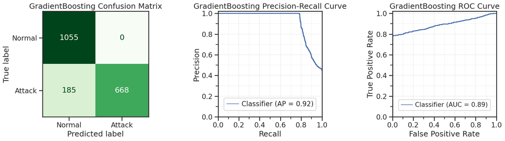

|  | final_model | test_accuracy | test_precision | test_recall | test_f1 | test_f2 | test_roc_auc | test_avg_precision |
| --- | --- | --- | --- | --- | --- | --- | --- | --- |
| 0 | GradientBoosting | 0.903 | 1.0 | 0.783 | 0.878 | 0.819 | 0.894 | 0.921 |

- When the model predicts Attack, it is extremely precise, but it misses a decent chunk of attacks.

## 10. Threshold Sensitivity For GradientBoosting

This section compares the default `0.50` threshold to a lower `0.30` threshold for the final `GradientBoosting` model using cross-validated predicted probabilities on the training split. We check if lowering the threshold will help boost recall at the expense of lower precision.

Threshold Sensitivity: Tradeoff

| model | threshold | accuracy | precision | recall | f1 | f2 | roc_auc | avg_precision | attacks_caught | missed_attacks | false_alarms | extra_attacks_caught | extra_false_alarms |
| --- | --- | --- | --- | --- | --- | --- | --- | --- | --- | --- | --- | --- | --- |
| GradientBoosting | 0.50 | 0.89 | 1.00 | 0.76 | 0.86 | 0.80 | 0.88 | 0.91 | 2,596 | 815 | 11 | +0 | +0 |
| GradientBoosting | 0.30 | 0.88 | 0.94 | 0.77 | 0.85 | 0.80 | 0.88 | 0.91 | 2,626 | 785 | 154 | +30 | +143 |

## 11. Most Important Features

This ranking uses the selected final model's `feature_importances_` values on the training split.

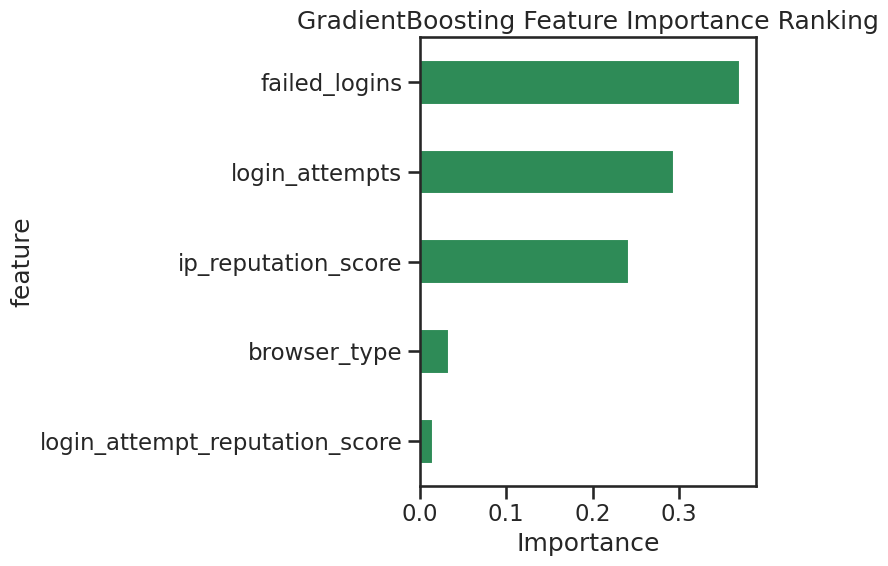

## 12. Model Deployment: Flask Demo App

The final trained pipeline is saved with `joblib` so it can be loaded into the Flask app demo. The app collects session behavior, prepares the same features used during training, and returns a Normal/Attack prediction with probabilities of it being an `Attack`.

```
../web_app/final_model.joblib
```

[output not shown]

## Username: **admin**

## Password: **password123**